# Testing Sums

Donny Williams

5/25/2020

# Introduction

This is a follow-up to the vignette [“Three Ways to Test the Same Hypothesis”](https://donaldrwilliams.github.io/BGGM/articles/hyp_3_ways.html). A new feature, `pcor_sum`, was added to **BGGM** that allows for testing partial correlation sums. This differs from the Bayes factor approach (“Approach #3”), in that only the posterior distribution is used to determine whether there is a difference in the sums.

### R package

```r
# need the developmental version
if (!requireNamespace("remotes")) {
  install.packages("remotes")
}

# install from github
remotes::install_github("donaldRwilliams/BGGM")
library(BGGM)
```

# One Group

This first example looks at one group, where a sum is tested within the same ptsd network. I focus on the relations between the re-experiencing (`B`) and avoidance (`C`) communities. In particular, the sum of relations between the “Intrusion” (5 nodes) community and the “Avoidance” (two nodes) community is tested.

## Sum to String

For the avoidance symptom “avoidance of thoughts” `C1`, this can be written in `R` code with

```
# ptsd
Y <- ptsd

# paste together sums
paste0(colnames(Y)[1:5],  "--C1", collapse = " + ")

#> "B1--C1 + B2--C1 + B3--C1 + B4--C1 + B5--C1"
```

whereas, for the avoidance symptom “avoidance of reminders” (`C2`), this is written as

```
paste0(colnames(Y)[1:5],  "--C2", collapse = " + ")

#> "B1--C2 + B2--C2 + B3--C2 + B4--C2 + B5--C2"
```

Note that typically this would have to be written out. `paste0` was used in this case to avoid typing out all of the relations.

## Fit Model

Here an ordinal GGM is fitted

```
fit <- estimate(Y+1, type = "ordinal", iter = 1000)
```

where the `+1` changes the first category from 0 to 1 (required).

## Test Sums

The next step is to use the `pcor_sum` function. First, I combine the sums into one string separated with `;`.

```
# sum 1
sum1 <- paste0(colnames(Y)[1:5],  "--C1", collapse = " + ")

# sum 2
sum2 <- paste0(colnames(Y)[1:5],  "--C2", collapse = " + ")

# paste together
sums <- paste(sum1, sum2, sep = ";")

# print
sums
#> "B1--C1 + B2--C1 + B3--C1 + B4--C1 + B5--C1;B1--C2 + B2--C2 + B3--C2 + B4--C2 + B5--C2"
```

Next `pcor_sum` is used

```
test_sum <- pcor_sum(fit, relations = sums)

# print
test_sum

# BGGM: Bayesian Gaussian Graphical Models
# ---
# Network Stats: Posterior Sum
# Posterior Samples: 1000
# ---
# Estimates
#
# Sum:
#                                    Post.mean Post.sd Cred.lb Cred.ub
# B1--C1+B2--C1+B3--C1+B4--C1+B5--C1     0.215   0.096   0.034   0.404
# B1--C2+B2--C2+B3--C2+B4--C2+B5--C2     0.334   0.097   0.145   0.514
# ---
#
# Difference:
# B1--C1+B2--C1+B3--C1+B4--C1+B5--C1 - B1--C2+B2--C2+B3--C2+B4--C2+B5--C2
#
#  Post.mean Post.sd Cred.lb Cred.ub Prob.greater Prob.less
#     -0.119   0.145  -0.409   0.173        0.205     0.795
# ---
```

`Prob.greater` is the posterior probability that the first sum is larger than the second sum.

## Plot Results

The object `test_sum` can then be plotted. Note this returns three plots, but only the difference is shown here

```
plot(test_sum)$diff
```

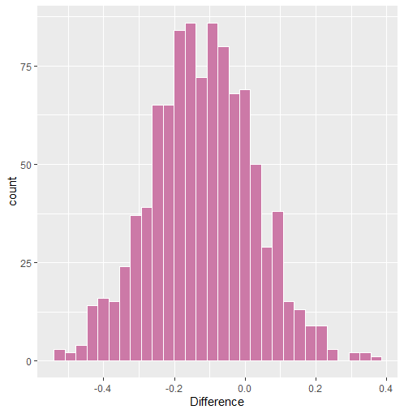

The histogram is not very smooth in this case because `iter = 1000`, but this of course can be changed.

# Two Groups

This next example is for two groups. The data are called `bfi` and they are in the **BGGM** package. I compare a sum of two relations for questions measuring agreeableness in males and females. The relations tested are as follows

## Sum to String

```r
sums <- c("A3--A4 + A4--A5")
```

## Fit Models

The next step is to fit the models

```r
# data
Y <- bfi

# males
Y_males <- subset(Y, gender == 1, select = -c(education, gender))[,1:5]

# females
Y_females <- subset(Y, gender == 2, select = -c(education, gender))[,1:5]


fit_female <- estimate(Y_females, seed = 2)

# fit males
fit_male <- estimate(Y_males, seed = 1)
```

## Test Sums

Then test the sum

```r
test_sum <- pcor_sum(fit_female, fit_male, relations = sums)

# print
test_sum
```

```
#> BGGM: Bayesian Gaussian Graphical Models
#> ---
#> Network Stats: Posterior Sum
#> Posterior Samples: 5000
#> ---
#> Estimates
#>
#> Sum:
#>                   Post.mean Post.sd Cred.lb Cred.ub
#> g1: A3--A4+A4--A5     0.292   0.026   0.241   0.342
#> g2: A3--A4+A4--A5     0.305   0.036   0.234   0.375
#> ---
#>
#> Difference:
#> g1: A3--A4+A4--A5 - g2: A3--A4+A4--A5
#>
#>  Post.mean Post.sd Cred.lb Cred.ub Prob.greater Prob.less
#>     -0.014   0.045    -0.1   0.074        0.386     0.614
#> ---
```

## Sanity Check

For a kind of sanity check, here is the sum for the male group obtained from the point estimates.

```r
pcor_mat(fit_male)["A3", "A4"] + pcor_mat(fit_male)["A4", "A5"]
```

```
#>  0.305
```

This matches the output.

# Notes

By default, the print function for `pcor_sum` provides 95 % credible intervals. This can be changed by directly using the print function, for example `print(test_sum, cred = 0.99)`, provides 99 % credible intervals.

Currently, this function only supports sums, due to this being of interest for the psychological network literature in particular. This can be extended to accommodate multiplication, subtraction, testing values other than zero, etc. Please make a feature request at either [github](https://github.com/donaldRwilliams/BGGM/issues) or [BGGM-users group](https://groups.google.com/forum/#!forum/bggm-users).